# thompson-ryan-ADA-data-reproduction

## Introduction

The subgranular zone (SGZ), located below the granule layer of the dentate gyrus (DG) region of the hippocampus, is one site of the brain that continues to birth new neurons throughout life, a process termed adult neurogenesis. Though neurogenesis begins high, newborn cells birth rates rapidly decline into adulthood. Facilitating adult neurogenesis promotes formation of new memories in the hippocampus. However, computational models predict that new cells added to the DG would also facilitate forgetting of established memories. The latter had not been shown in vivo models, and this study was intended to explore this possibility. The authors found that, as hypothesized, increased neurogenesis after a learning task was sufficient to induce forgetting.

## Data analysis replication

### Fig1C

Importing file for Fig1c.

```r
###### Importing Fig1C

Fig1C <- read.csv("forgetting-data/Fig1C.csv")
head(Fig1C)
```

```
##   Age GFP..cells
## 1  17       0.79
## 2  17       1.23
## 3  17       0.80
## 4  17       0.89
## 5  60       0.07
## 6  60       0.03
```

Analysis of Fig1C using two sample t-test. T value is different from that reported in text (t6 = 8.57, P < 0.001).

```r
# t-test between 17 and 60 GFP+ cells !!!t value different
t_test(GFP..cells ~ Age, data = Fig1C, var.equal = TRUE)
```

```
##
##  Two Sample t-test
##
## data:  GFP..cells by Age
## t = 8.5124, df = 6, p-value = 0.0001439
## alternative hypothesis: true difference in means is not equal to 0
## 95 percent confidence interval:
##  0.6288234 1.1361766
## sample estimates:
## mean in group 17 mean in group 60
##           0.9275           0.0450
```

Preparing data to be plotted by calculating mean and standard error.

```r
# Tibble with mean and standard error Fig1C
Fig1C_mean <- favstats(GFP..cells ~ Age, data = Fig1C) %>%
  mutate(se = sd/sqrt(n))
head(Fig1C_mean)
```

```
##   Age  min     Q1 median     Q3  max   mean         sd n missing          se
## 1  17 0.79 0.7975  0.845 0.9750 1.23 0.9275 0.20661962 4       0 0.103309809
## 2  60 0.03 0.0375  0.040 0.0475 0.07 0.0450 0.01732051 4       0 0.008660254
```

Creating plot for Fig1C.

```r
# Plot for above data
p1 <- ggplot(data = Fig1C_mean, aes(x = Age, y = mean, fill = Age)) +
  theme_classic() + #no grid and dark axis lines
  theme(axis.text.x = element_blank(), #hides text and ticks
        axis.ticks.x = element_blank(),
        legend.title = element_blank(),
        legend.position = c(0.35, 1)) +
  geom_errorbar(aes(ymin = mean - se, ymax = mean + se), width = 0.15, size = 1, color=c("#1aa700", "#2294d0")) + #error bar before mean bar hides lower
  geom_bar(stat= "identity") +
  labs(x = "", y= "GFP+ Cells", tag = "C") + #no x label
  coord_cartesian(ylim = c(0, 1.6)) +
  scale_y_continuous(breaks = c(0, 0.8, 1.6), expand = c(0,0)) + #breaks to match fig, expand puts bars directly on axis
  geom_signif(comparisons = list(c("17", "60")), #ggsignif to add significance line
              annotation = "*") +
  scale_fill_manual("Age", values = c("17" = "#1aa700", "60" = "#2294d0"), labels = c("P17", "P60")) #bar colors
```

### FigS1

Importing file for Fig1DEF and FigS1.

```r
###### Importing Fig1DEF

Fig1DEF <- read.csv("forgetting-data/Fig1DEF_ and_FigS1.csv", stringsAsFactors = FALSE)
head(Fig1DEF)
```

```
##   Age Ki67..cells DCX..cells DCX..LMTs
## 1  17        0.93       2.05     10.82
## 2  17        0.53       2.08      9.39
## 3  17        1.25       2.35     10.26
## 4  17        0.63       1.99      8.93
## 5  17        0.90          n         n
## 6  28        0.24          n         n
```

Factoring age and adding id column to perform ANOVA.

```r
# Manipulating data for ANOVA
Fig1DEF <- Fig1DEF %>%
  mutate(Age_f = factor(Age, levels = c("17", "28", "60", "120", "180"))) %>%
  mutate(id = rownames(Fig1DEF))
head(Fig1DEF)
```

```
##   Age Ki67..cells DCX..cells DCX..LMTs Age_f id
## 1  17        0.93       2.05     10.82    17  1
## 2  17        0.53       2.08      9.39    17  2
## 3  17        1.25       2.35     10.26    17  3
## 4  17        0.63       1.99      8.93    17  4
## 5  17        0.90          n         n    17  5
## 6  28        0.24          n         n    28  6
```

Performing the ANOVA for FigS1.

```r
# ANOVA
one_fit <- aov_ez("id", "Ki67..cells", data = Fig1DEF, between = c("Age_f"))
```

```
## Contrasts set to contr.sum for the following variables: Age_f
```

```r
one_fit
```

```
## Anova Table (Type 3 tests)
##
## Response: Ki67..cells
##   Effect    df  MSE         F ges p.value
## 1  Age_f 4, 17 0.02 23.62 *** .85  <.0001
## ---
## Signif. codes:  0 '***' 0.001 '**' 0.01 '*' 0.05 '+' 0.1 ' ' 1
```

Preparing data to be plotted by calculating mean and standard error.

```r
# Tibble for visualizing FigS1
FigS1_mean <- favstats(Ki67..cells ~ Age_f, data = Fig1DEF) %>%
  mutate(Age_f = factor(Age_f, levels = c("17", "28", "60", "120", "180"))) %>%
  mutate(se = sd/sqrt(n))
head(FigS1_mean)
```

```
##   Age_f  min     Q1 median    Q3  max   mean         sd n missing          se
## 1    17 0.53 0.6300  0.900 0.930 1.25 0.8480 0.28270126 5       0 0.126427845
## 2    28 0.20 0.2400  0.240 0.280 0.30 0.2520 0.03898718 5       0 0.017435596
## 3    60 0.08 0.1550  0.185 0.210 0.27 0.1800 0.07788881 4       0 0.038944405
## 4   120 0.08 0.0875  0.105 0.125 0.14 0.1075 0.02753785 4       0 0.013768926
## 5   180 0.04 0.0625  0.075 0.080 0.08 0.0675 0.01892969 4       0 0.009464847
```

Creating plot for FigS1.

```r
# Plotting FigS1
sp1 <- ggplot(data = FigS1_mean, aes(x = Age_f, y = mean, group = 1)) +
  geom_line(color = "#1aa700", size = 1) +
  geom_point(color = "#1aa700", size = 4) +
  geom_errorbar(aes(ymin = mean - se, ymax = mean + se), width = .1, size = 1, color=c("#1aa700")) +
  labs(x = "Age (days)", y = "Ki67+ cells") +
  theme_classic() +
  scale_y_continuous(breaks = c(0, 0.5, 1))
```

### Fig1D

Filtering Fig1DEF to only have P17 and P60.

```r
# Filtering for only ages 17 and 60
Fig1DEF_working <- Fig1DEF %>%
  filter(Age_f %in% c("17", "60"))
head(Fig1DEF_working)
```

```
##   Age Ki67..cells DCX..cells DCX..LMTs Age_f id
## 1  17        0.93       2.05     10.82    17  1
## 2  17        0.53       2.08      9.39    17  2
## 3  17        1.25       2.35     10.26    17  3
## 4  17        0.63       1.99      8.93    17  4
## 5  17        0.90          n         n    17  5
## 6  60        0.19       0.38      2.45    60 11
```

Analysis of Fig1D using two sample t-test.

```r
# t-test for Fig1D
t_test(Ki67..cells ~ Age, data = Fig1DEF_working, var.equal = TRUE)
```

```
##
##  Two Sample t-test
##
## data:  Ki67..cells by Age
## t = 4.5325, df = 7, p-value = 0.002692
## alternative hypothesis: true difference in means is not equal to 0
## 95 percent confidence interval:
##  0.3195017 1.0164983
## sample estimates:
## mean in group 17 mean in group 60
##            0.848            0.180
```

Preparing data to be plotted by calculating mean and standard error.

```r
# Tibble with mean and standard error Fig1D
Fig1D_mean <- favstats(Ki67..cells ~ Age, data = Fig1DEF_working) %>%
  mutate(se = sd/sqrt(n))
head(Fig1D_mean)
```

```
##   Age  min    Q1 median   Q3  max  mean         sd n missing        se
## 1  17 0.53 0.630  0.900 0.93 1.25 0.848 0.28270126 5       0 0.1264278
## 2  60 0.08 0.155  0.185 0.21 0.27 0.180 0.07788881 4       0 0.0389444
```

Creating plot for Fig1D.

```r
# Plotting Fig1D
p2 <- ggplot(data = Fig1D_mean, aes(x = Age, y = mean, fill = Age)) +
  geom_errorbar(aes(ymin = mean - se, ymax = mean + se), width = 0.15, size = 1, color=c("#1aa700", "#2294d0")) + #error bar   before mean bar hides lower
  geom_bar(stat= "identity") +
  labs(x = "", y= "Ki67+ Cells", tag = "D") + #no x label
  coord_cartesian(ylim = c(0, 1.4)) +
  scale_y_continuous(breaks = c(0, 0.7, 1.4), expand = c(0,0)) + #breaks to match fig, expand puts bars directly on axis
  theme_classic() + #no grid and dark axis lines
  theme(axis.text.x = element_blank(), #hides text and ticks
        axis.ticks.x = element_blank(),
        legend.position = "none") + #removes legend
  geom_signif(comparisons = list(c("17", "60")), #ggsignif to add significance line
              annotation = "*") +
  scale_fill_manual("Age", values = c("17" = "#1aa700", "60" = "#2294d0")) #bar colors
```

### Fig1E

Removing missing values to make analyses and plotting easier for Fig1E and F.

```r
# Removing NA
Fig1DEF_working <- Fig1DEF_working[-5,] %>%
  mutate(DCX..cells = as.numeric(DCX..cells),
         DCX..LMTs = as.numeric(DCX..LMTs))
head(Fig1DEF_working)
```

```
##   Age Ki67..cells DCX..cells DCX..LMTs Age_f id
## 1  17        0.93       2.05     10.82    17  1
## 2  17        0.53       2.08      9.39    17  2
## 3  17        1.25       2.35     10.26    17  3
## 4  17        0.63       1.99      8.93    17  4
## 5  60        0.19       0.38      2.45    60 11
## 6  60        0.18       0.31      3.11    60 12
```

Analysis of Fig1E using two sample t-test.

```r
# t-test for DCX cells
t_test(DCX..cells ~ Age, data = Fig1DEF_working, var.equal = TRUE)
```

```
##
##  Two Sample t-test
##
## data:  DCX..cells by Age
## t = 18.646, df = 6, p-value = 1.536e-06
## alternative hypothesis: true difference in means is not equal to 0
## 95 percent confidence interval:
##  1.476908 1.923092
## sample estimates:
## mean in group 17 mean in group 60
##           2.1175           0.4175
```

Preparing data to be plotted by calculating mean and standard error.

```r
# Tibble with mean and standard error Fig1E
Fig1E_mean <- favstats(DCX..cells ~ Age, data = Fig1DEF_working) %>%
  mutate(se = sd/sqrt(n))
head(Fig1E_mean)
```

```
##   Age  min     Q1 median     Q3  max   mean         sd n missing         se
## 1  17 1.99 2.0350  2.065 2.1475 2.35 2.1175 0.15945219 4       0 0.07972609
## 2  60 0.31 0.3625  0.435 0.4900 0.49 0.4175 0.08845903 4       0 0.04422952
```

Creating plot for Fig1E.

```r
# Plotting Fig1E
p3 <- ggplot(data = Fig1E_mean, aes(x = Age, y = mean, fill = Age)) +
  geom_errorbar(aes(ymin = mean - se, ymax = mean + se), width = 0.15, size = 1, color=c("#1aa700", "#2294d0")) + #error bar   before mean bar hides lower
  geom_bar(stat= "identity") +
  labs(x = "", y= "DCX+ Cells", tag = "E") + #no x label
  coord_cartesian(ylim = c(0, 3.6)) +
  scale_y_continuous(breaks = c(0, 1.8, 3.6), expand = c(0,0)) + #breaks to match fig, expand puts bars directly on axis
  theme_classic() + #no grid and dark axis lines
  theme(axis.text.x = element_blank(), #hides text and ticks
        axis.ticks.x = element_blank(),
        legend.position = "none") + #removes legend
  geom_signif(comparisons = list(c("17", "60")), #ggsignif to add significance line
              annotation = "*") +
  scale_fill_manual("Age", values = c("17" = "#1aa700", "60" = "#2294d0")) #bar colors
```

### Fig1F

Analysis of Fig1F using two sample t-test.

```r
# t-test for LMTs
t_test(DCX..LMTs ~ Age, data = Fig1DEF_working, var.equal = TRUE)
```

```
##
##  Two Sample t-test
##
## data:  DCX..LMTs by Age
## t = 15.034, df = 6, p-value = 5.456e-06
## alternative hypothesis: true difference in means is not equal to 0
## 95 percent confidence interval:
##  5.770723 8.014277
## sample estimates:
## mean in group 17 mean in group 60
##           9.8500           2.9575
```

Preparing data to be plotted by calculating mean and standard error.

```r
# Tibble with mean and standard error Fig1F
Fig1F_mean <- favstats(DCX..LMTs ~ Age, data = Fig1DEF_working) %>%
  mutate(se = sd/sqrt(n))
head(Fig1F_mean)
```

```
##   Age  min     Q1 median     Q3   max   mean        sd n missing        se
## 1  17 8.93 9.2750  9.825 10.400 10.82 9.8500 0.8499020 4       0 0.4249510
## 2  60 2.45 2.9075  3.085  3.135  3.21 2.9575 0.3440325 4       0 0.1720162
```

Creating plot for Fig1F.

```r
# Plotting fig1F
p4 <- ggplot(data = Fig1F_mean, aes(x = Age, y = mean, fill = Age)) +
  geom_errorbar(aes(ymin = mean - se, ymax = mean + se), width = 0.15, size = 1, color=c("#1aa700", "#2294d0")) + #error bar   before mean bar hides lower
  geom_bar(stat= "identity") +
  labs(x = "", y= "DCX+ LMTs", tag = "F") + #no x label
  coord_cartesian(ylim = c(0, 16)) +
  scale_y_continuous(breaks = c(0, 8, 16), expand = c(0,0)) + #breaks to match fig, expand puts bars directly on axis
  theme_classic() + #no grid and dark axis lines
  theme(axis.text.x = element_blank(), #hides text and ticks
        axis.ticks.x = element_blank(),
        legend.position = "none") + #removes legend
  geom_signif(comparisons = list(c("17", "60")), #ggsignif to add significance line
              annotation = "*") +
  scale_fill_manual("Age", values = c("17" = "#1aa700", "60" = "#2294d0")) #bar colors
```

### Fig1H

Importing file for Fig1H and FigS3B and adding id column.

```r
###### Importing Fig1H_and_FigS3B
Fig1H_and_FigS3b <- read.csv("forgetting-data/Fig1H_ and_FigS3b.csv", stringsAsFactors = FALSE) %>%
  mutate(id = c(1:70))
head(Fig1H_and_FigS3b)
```

```
##   Age Day Train.Min..1.Freezing Train.Min..1.Freezing.1 Train.Min..1.Freezing.2
## 1  17   1                 10.79                   11.62                   13.69
## 2  17   1                 10.79                    4.98                   91.70
## 3  17   1                  6.22                    9.13                    9.96
## 4  17   1                  0.00                    0.00                   42.74
## 5  17   1                  3.32                   18.26                   53.94
## 6  17   1                  0.00                    0.00                   39.42
##   Train.Min..1.Freezing.3 Train.Min..1.Freezing.4 Test.Freezing id
## 1                   79.67                   84.17         69.47  1
## 2                   83.40                   70.42         64.41  2
## 3                   77.18                   90.83         75.41  3
## 4                   71.78                   82.92         32.62  4
## 5                   76.76                   66.25         25.91  5
## 6                   51.87                   79.17         71.18  6
```

Analysis of Fig1H using a 2 way ANOVA.

```r
# ANOVA

two_fit <- aov_ez("id", "Test.Freezing", data = Fig1H_and_FigS3b,
                  between = c("Age", "Day"))
```

```
## Converting to factor: Age, Day
```

```
## Contrasts set to contr.sum for the following variables: Age, Day
```

```r
two_fit
```

```
## Anova Table (Type 3 tests)
##
## Response: Test.Freezing
##    Effect    df    MSE          F ges p.value
## 1     Age 1, 62 220.25 236.57 *** .79  <.0001
## 2     Day 3, 62 220.25  12.32 *** .37  <.0001
## 3 Age:Day 3, 62 220.25  13.07 *** .39  <.0001
## ---
## Signif. codes:  0 '***' 0.001 '**' 0.01 '*' 0.05 '+' 0.1 ' ' 1
```

Post hoc t-testss for age by day.

```r
posthoc <- pairs(emmeans(two_fit, "Age", by = "Day"), adjust = "none")
posthoc
```

```
## Day = 1:
##  contrast estimate   SE df t.ratio p.value
##  17 - 60     -20.3 7.00 62  -2.900 0.0052
##
## Day = 7:
##  contrast estimate   SE df t.ratio p.value
##  17 - 60     -50.4 7.21 62  -6.984 <.0001
##
## Day = 14:
##  contrast estimate   SE df t.ratio p.value
##  17 - 60     -74.8 7.21 62 -10.370 <.0001
##
## Day = 28:
##  contrast estimate   SE df t.ratio p.value
##  17 - 60     -73.1 7.00 62 -10.450 <.0001
```

Preparing data to be plotted by caluating mean and standard error. Day was mutated to a factor so that the x-axis ticks were evenly spaced.

```r
# Manipulating data for visualization
Fig1H_mean <- Fig1H_and_FigS3b %>%
  group_by(Age, Day) %>%
  summarize(mean = mean(Test.Freezing),
            sd = sd(Test.Freezing),
            se = sd/sqrt(n())) %>%
  mutate(Day_f = factor(Day, levels = c("1", "7", "14", "28")))
head(Fig1H_mean)
```

```
## # A tibble: 6 x 6
## # Groups:   Age [2]
##     Age   Day  mean    sd     se Day_f
##   <int> <int> <dbl> <dbl>  <dbl> <fct>
## 1    17     1 54.6  18.6   6.19  1
## 2    17     7 28.5  30.7  10.2   7
## 3    17    14  3.28  3.25  1.08  14
## 4    17    28  1.48  2.48  0.826 28
## 5    60     1 74.9  12.3   4.09  1
## 6    60     7 78.8   4.99  1.76  7
```

Creating plot for Fig1H.

```r
# Plotting Fig1H
p5 <- ggplot(data = Fig1H_mean, aes(x = Day_f, y = mean, group = factor(Age), color = factor(Age))) +
  geom_point(size = 4) +
  geom_line() +
  geom_errorbar(aes(ymin = mean - se, ymax = mean + se), width = 0.1) +
  labs(x = "Day", y= "Freezing (%)", tag = "H") +
  coord_cartesian(ylim = c(0, 100)) +
  scale_y_continuous(breaks = c(0, 50, 100), expand = c(0,0)) +
  scale_color_manual(values = c("#1aa700", "#2294d0"), labels = c("P17", "P60")) +
  theme_classic() + #no grid and dark axis lines
  theme(axis.ticks.x = element_blank(), legend.title = element_blank(), legend.position = "top") +
  geom_signif(y_position = c(84), xmin = c(1:4), xmax = c(1:4), annotation = "*", color = "black", tip_length = 0, size = 0)
```

### FigS3b

No analyses were done for the data in FigS3B.

Preparing data to be visualized for FigS3B by pivoting each train.min column under the minute column and values in the freezing column.

```r
# Manipulating for figure S3b
FigS3b <- pivot_longer(data = Fig1H_and_FigS3b, cols = c("Train.Min..1.Freezing", "Train.Min..1.Freezing.1",
                                                         "Train.Min..1.Freezing.2", "Train.Min..1.Freezing.3",
                                                         "Train.Min..1.Freezing.4"),
                       names_to = "minute", values_to = "freezing")
head(FigS3b)
```

```
## # A tibble: 6 x 6
##     Age   Day Test.Freezing    id minute                  freezing
##   <int> <int>         <dbl> <int> <chr>                      <dbl>
## 1    17     1          69.5     1 Train.Min..1.Freezing       10.8
## 2    17     1          69.5     1 Train.Min..1.Freezing.1     11.6
## 3    17     1          69.5     1 Train.Min..1.Freezing.2     13.7
## 4    17     1          69.5     1 Train.Min..1.Freezing.3     79.7
## 5    17     1          69.5     1 Train.Min..1.Freezing.4     84.2
## 6    17     1          64.4     2 Train.Min..1.Freezing       10.8
```

Preparing data to be plotted by calulating mean and standard error.

```r
# Manipulation for visualization
FigS3b_mean <- FigS3b %>%
  group_by(Age, minute) %>%
  summarize(mean = mean(freezing),
             sd = sd(freezing),
             se = sd/sqrt(n()))
head(FigS3b_mean)
```

```
## # A tibble: 6 x 5
## # Groups:   Age [2]
##     Age minute                     mean     sd     se
##   <int> <chr>                     <dbl>  <dbl>  <dbl>
## 1    17 Train.Min..1.Freezing    5.41    7.56  1.26
## 2    17 Train.Min..1.Freezing.1  6.51    7.66  1.28
## 3    17 Train.Min..1.Freezing.2 45.6    26.0   4.34
## 4    17 Train.Min..1.Freezing.3 65.5    22.1   3.68
## 5    17 Train.Min..1.Freezing.4 78.3    12.7   2.12
## 6    60 Train.Min..1.Freezing    0.0609  0.355 0.0609
```

Creating plot for Fig3SB.

```r
# Plotting FS3b

sp2 <- ggplot(data = FigS3b_mean, aes(x = minute, y = mean, group = factor(Age), color = factor(Age))) +
  geom_point(size = 4) +
  geom_line(size = 1) +
  geom_errorbar(aes(ymin = mean - se, ymax = mean + se), width = 0.05, size = 1) +
  labs(x = "Minute", y= "Freezing (%)") +
  coord_cartesian(ylim = c(0, 100)) +
  scale_y_continuous(breaks = c(0, 50, 100), expand = c(0,0)) +
  theme_classic() + #no grid and dark axis lines
  scale_color_manual(values = c("#1aa700", "#2294d0"), labels = c("P17", "P60")) +
  theme(legend.title = element_blank(), legend.position = c(0.075, 0.95)) +
  scale_x_discrete(labels = c("1", "2", "3", "4", "5"))
```

### Fig1I

Importing file for Fig1I.

```r
###### Importing Fig1I
Fig1I <- read.csv("forgetting-data/Fig1I.csv", stringsAsFactors = FALSE)
head(Fig1I)
```

```
##   Age Before.shock During.shock
## 1  17         0.43         4.73
## 2  17         0.77         6.95
## 3  17         1.01         7.08
## 4  17         0.40         8.29
## 5  17         1.12         9.08
## 6  17         0.61         9.29
```

preparing data for ANOVA by pivotting shock columns to condition column and value to distance.traveled. Also factoring age and condition in addition to adding id column.

```r
# Manipulating data to do ANOVA
Fig1I <- pivot_longer(data = Fig1I, cols= ends_with(".shock"),
                      names_to= "condition", values_to = "Distance.traveled") %>%
  mutate(Age_f = factor(Age, levels = c("17", "60")),
         condition_f = factor(condition, levels = c("Before.shock", "During.shock")),
         id = c(1:34))
head(Fig1I)
```

```
## # A tibble: 6 x 6
##     Age condition    Distance.traveled Age_f condition_f     id
##   <int> <chr>                    <dbl> <fct> <fct>        <int>
## 1    17 Before.shock              0.43 17    Before.shock     1
## 2    17 During.shock              4.73 17    During.shock     2
## 3    17 Before.shock              0.77 17    Before.shock     3
## 4    17 During.shock              6.95 17    During.shock     4
## 5    17 Before.shock              1.01 17    Before.shock     5
## 6    17 During.shock              7.08 17    During.shock     6
```

Analysis of Fig1I using 2 way ANOVA.

```r
# The test
two_fit2 <- aov_ez("id", "Distance.traveled", data = Fig1I,
                  between = c("Age_f", "condition_f"))
```

```
## Contrasts set to contr.sum for the following variables: Age_f, condition_f
```

```r
two_fit2
```

```
## Anova Table (Type 3 tests)
##
## Response: Distance.traveled
##              Effect    df  MSE          F  ges p.value
## 1             Age_f 1, 30 2.11     3.88 +  .11     .06
## 2       condition_f 1, 30 2.11 258.23 ***  .90  <.0001
## 3 Age_f:condition_f 1, 30 2.11       0.25 .008     .62
## ---
## Signif. codes:  0 '***' 0.001 '**' 0.01 '*' 0.05 '+' 0.1 ' ' 1
```

Preparing data to be plotted by calculating mean and standard error.

```r
# Manipulating data for visualization
Fig1I_mean <- Fig1I %>%
  group_by(Age, condition) %>%
  summarize(mean = mean(Distance.traveled),
            sd = sd(Distance.traveled),
            se = sd/sqrt(n()))
head(Fig1I_mean)
```

```
## # A tibble: 4 x 5
## # Groups:   Age [2]
##     Age condition     mean    sd     se
##   <int> <chr>        <dbl> <dbl>  <dbl>
## 1    17 Before.shock 0.632 0.307 0.102
## 2    17 During.shock 8.40  2.02  0.673
## 3    60 Before.shock 1.37  0.253 0.0894
## 4    60 During.shock 9.63  2.05  0.724
```

Creating plot for Fig1I

```r
# Plotting Fig1I
p6 <- ggplot(data = Fig1I_mean, aes(x = condition, y = mean, group = Age)) +
  geom_point(size = 4, color = c("#1aa700", "#1aa700","#2294d0", "#2294d0")) +
  geom_line(color = c("#1aa700", "#1aa700","#2294d0", "#2294d0")) +
  geom_errorbar(aes(ymin = mean - se, ymax = mean + se), width = 0.05, size = 1,
                color = c("#1aa700", "#1aa700","#2294d0", "#2294d0")) +
  labs(x = "Shock Reactivity", y= "Distance Traveled", tag = "I") +
  coord_cartesian(ylim = c(0, 12)) +
  scale_y_continuous(breaks = c(0, 6, 12), expand = c(0,0)) +
  theme_classic() + #no grid and dark axis lines
  scale_x_discrete(labels = c("Before", "After"))
```

### Plotting

Recreating Figure 1. Cropped image from paper below.

[figure not shown]

```r
# Visualization
lay <- rbind(c(1,2,3,4),
             c(NA,6,7,NA))
grid.arrange(p1, p2, p3, p4, p5, p6, layout_matrix = lay)
```

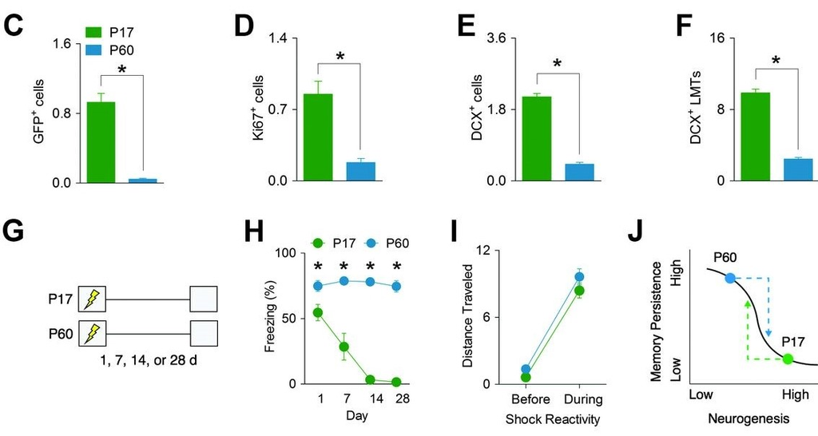

```r
knitr::include_graphics("images/F1.large.cropped.jpg")
```

Recreating FigS1. Cropped image from paper below.

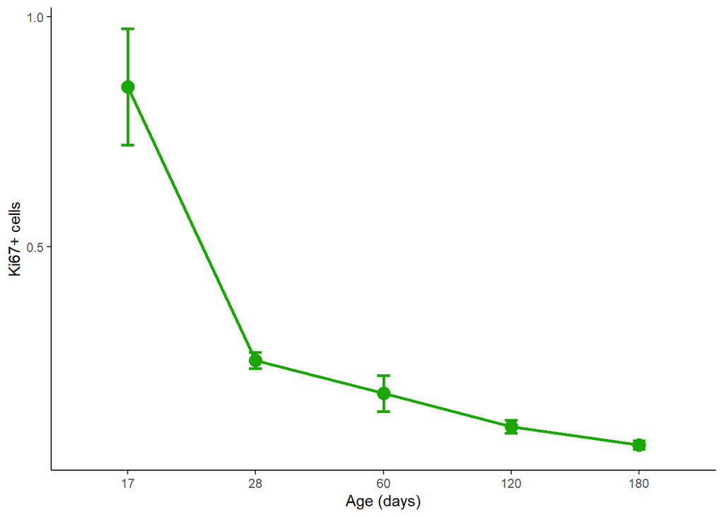

```r
sp1
```

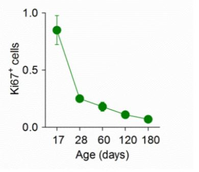

```r
knitr::include_graphics("images/FS1.jpg")
```

Recreating FigS3B. Cropped image from paper below.

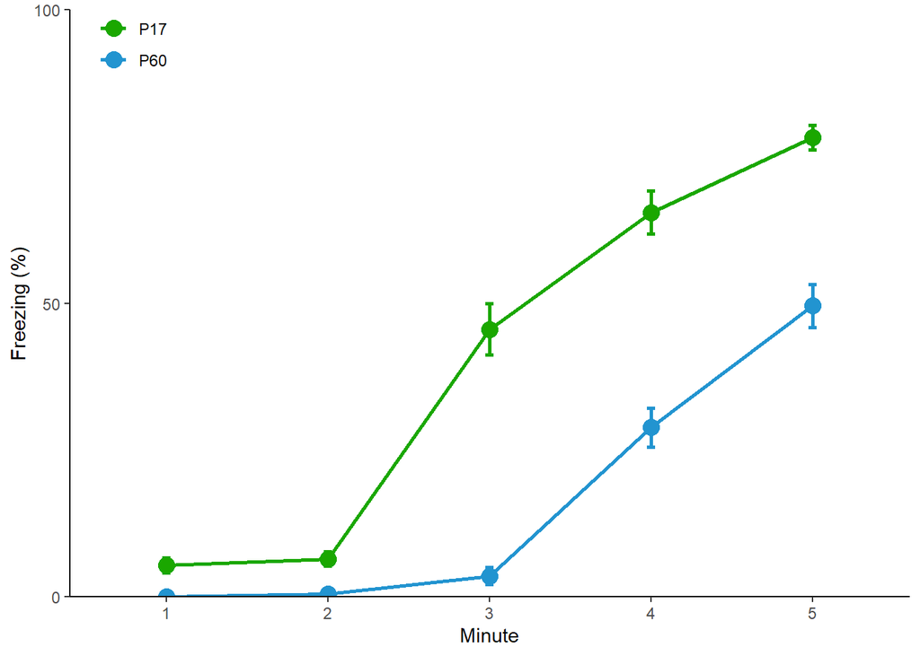

```r
sp2
```

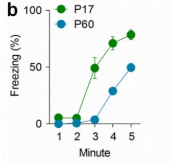

```r
knitr::include_graphics("images/FS3B.jpg")
```

## Discussion and Reflection

Overall, the data replication for Figures 1, S1 and S3B were successful. Fig1C-F used a two sample t-test to compare PD17 and PD60 mice. Fig1C compared GFP+ cells, I found t6= 8.51, P<0.001 while the author’s reported t6=8.57, P<0.001. Considering the degrees of freedom matched and two sample t-test was done for all other data reported in fig1C-F, I believe this was a data entry mistake in their report. Every other data analyzed matched that reported in the original.

Fig1D found Ki67+ cells higher in PD17 compared to PD60 (t7=4.53, P< 0.01). Fig1E found DCX+ cells higher in PD17 compared to PD60 (t6=18.65, P<0.001). Fig1F found DCX+ LMTs higher in PD17 compared to PD60 (t6=15.03, P<0.001). FigS1 extended Fig1D findings by comparing Ki67+ cells in PD17, PD28, PD60, PD120, and PD180 mice using a one way ANOVA. A main effect was found for age (F4,17= 23.62, P<0.001).

Fig1H compared % freezing, as a measure of forgetting, in contextual fear conditioning after different intervals for PD17 and PD60 mice using a two-way ANOVA. Post hoc t-tests comparing age by day followed (1 day, P < 0.05; 7 days, P < 0.001; 14 days, P < 0.001; 28 days, P < 0.001). A main effect was found for age x day (F3,62= 13.07, P< 0.001). Fig1I compared distance traveled in PD17 and PD60 mice before and during shock as a measure of reactivity to the shock stimulus. No difference was found in reactivity between the two age groups (F1,30= 0.25, P=0.62).

Formatting the visualization of the data to match that of the original publication was the most demanding task, especially when using grid.arrange() since that applies additional formatting to a plot compared to how it would look rendered alone. This took some time making changes and reknitting the document to make it aesthetically pleasing.